# **Project on Predicting the Presence of Corona Virus based on Region**

# **Project Overview**

###### The Corona virus dataset contains the data related to places which are effected by the virus , the main objective of this dataset is to create a model which can help us in predicition the Presence of Corona Virus based on given Latitude and Longitude . For this classification we have used Naive Bayes Classifier under Gaussian model.

**Data Information** The dataset contains- 5822 records samples of different countries all over the world.

**Attribute Information:**

1. Province/State
2. Country/Region
3. Latitude
4. Longitude
5. Date
6. Confirmed
7. Deaths
8. Recovered  
   --- If The case in confirmed then that Region in Effected

## **Steps to Follow**

**Step 1 -** Preprocessing of Data  
**Step 2 -** Representation of Data in Figure  
**Step 3 -** Spliting of Data (Train and Test)  
**Step 4 -** Model Building and Predicting  
**Step 5 -** Cross Validation Score

## Step 1- Preprocessing of Data

#### Import libraries numpy for N-D data pandas for data analysis and manipulation tool

```python
import numpy as np
import pandas as pd
```

### Convertion of data in csv to dataframe

```python
df=pd.read_csv("covid_19_clean_complete.csv")
df
```

|  | Province/State | Country/Region | Lat | Long | Date | Confirmed | Deaths | Recovered |
| --- | --- | --- | --- | --- | --- | --- | --- | --- |
| 0 | Anhui | Mainland China | 31.8257 | 117.2264 | 1/22/20 | 1 | 0 | 0 |
| 1 | Beijing | Mainland China | 40.1824 | 116.4142 | 1/22/20 | 14 | 0 | 0 |
| 2 | Chongqing | Mainland China | 30.0572 | 107.8740 | 1/22/20 | 6 | 0 | 0 |
| 3 | Fujian | Mainland China | 26.0789 | 117.9874 | 1/22/20 | 1 | 0 | 0 |
| 4 | Gansu | Mainland China | 36.0611 | 103.8343 | 1/22/20 | 0 | 0 | 0 |
| ... | ... | ... | ... | ... | ... | ... | ... | ... |
| 5817 | Placer County, CA | US | 39.0916 | -120.8039 | 3/2/20 | 1 | 0 | 0 |
| 5818 | San Mateo, CA | US | 37.5630 | -122.3255 | 3/2/20 | 1 | 0 | 0 |
| 5819 | Sarasota, FL | US | 27.3364 | -82.5307 | 3/2/20 | 1 | 0 | 0 |
| 5820 | Sonoma County, CA | US | 38.5780 | -122.9888 | 3/2/20 | 1 | 0 | 0 |
| 5821 | Umatilla, OR | US | 45.7750 | -118.7606 | 3/2/20 | 1 | 0 | 0 |

5822 rows × 8 columns

### Since Deaths and Recovered in not used to predict present or absent of virus we are removing those fields

```python
df.drop(["Deaths","Recovered"],axis=1,inplace=True)
df
```

|  | Province/State | Country/Region | Lat | Long | Date | Confirmed |
| --- | --- | --- | --- | --- | --- | --- |
| 0 | Anhui | Mainland China | 31.8257 | 117.2264 | 1/22/20 | 1 |
| 1 | Beijing | Mainland China | 40.1824 | 116.4142 | 1/22/20 | 14 |
| 2 | Chongqing | Mainland China | 30.0572 | 107.8740 | 1/22/20 | 6 |
| 3 | Fujian | Mainland China | 26.0789 | 117.9874 | 1/22/20 | 1 |
| 4 | Gansu | Mainland China | 36.0611 | 103.8343 | 1/22/20 | 0 |
| ... | ... | ... | ... | ... | ... | ... |
| 5817 | Placer County, CA | US | 39.0916 | -120.8039 | 3/2/20 | 1 |
| 5818 | San Mateo, CA | US | 37.5630 | -122.3255 | 3/2/20 | 1 |
| 5819 | Sarasota, FL | US | 27.3364 | -82.5307 | 3/2/20 | 1 |
| 5820 | Sonoma County, CA | US | 38.5780 | -122.9888 | 3/2/20 | 1 |
| 5821 | Umatilla, OR | US | 45.7750 | -118.7606 | 3/2/20 | 1 |

5822 rows × 6 columns

### Creating labelEncoder for Date field to make it int because its in object type in pandas dataframe

```python
from sklearn import preprocessing

le = preprocessing.LabelEncoder()
df["DateLE"]=le.fit_transform(df["Date"].values)
df
```

|  | Province/State | Country/Region | Lat | Long | Date | Confirmed | DateLE |
| --- | --- | --- | --- | --- | --- | --- | --- |
| 0 | Anhui | Mainland China | 31.8257 | 117.2264 | 1/22/20 | 1 | 0 |
| 1 | Beijing | Mainland China | 40.1824 | 116.4142 | 1/22/20 | 14 | 0 |
| 2 | Chongqing | Mainland China | 30.0572 | 107.8740 | 1/22/20 | 6 | 0 |
| 3 | Fujian | Mainland China | 26.0789 | 117.9874 | 1/22/20 | 1 | 0 |
| 4 | Gansu | Mainland China | 36.0611 | 103.8343 | 1/22/20 | 0 | 0 |
| ... | ... | ... | ... | ... | ... | ... | ... |
| 5817 | Placer County, CA | US | 39.0916 | -120.8039 | 3/2/20 | 1 | 40 |
| 5818 | San Mateo, CA | US | 37.5630 | -122.3255 | 3/2/20 | 1 | 40 |
| 5819 | Sarasota, FL | US | 27.3364 | -82.5307 | 3/2/20 | 1 | 40 |
| 5820 | Sonoma County, CA | US | 38.5780 | -122.9888 | 3/2/20 | 1 | 40 |
| 5821 | Umatilla, OR | US | 45.7750 | -118.7606 | 3/2/20 | 1 | 40 |

5822 rows × 7 columns

### Creating a new Field "Results" such that it says Present for all those records which have value 1 or more in "Confirmed" field else Absent

```python
df["Results"]=df["Confirmed"]!=0
df.replace(to_replace=True,value="Present",inplace=True)
df.replace(to_replace=False,value="Absent",inplace=True)
```

```python
from collections import Counter
Counter(df["Results"])
```

```
Counter({'Present': 3048, 'Absent': 2774})
```

```python
df.head()
```

|  | Province/State | Country/Region | Lat | Long | Date | Confirmed | DateLE | Results |
| --- | --- | --- | --- | --- | --- | --- | --- | --- |
| 0 | Anhui | Mainland China | 31.8257 | 117.2264 | 1/22/20 | 1 | 0 | Present |
| 1 | Beijing | Mainland China | 40.1824 | 116.4142 | 1/22/20 | 14 | 0 | Present |
| 2 | Chongqing | Mainland China | 30.0572 | 107.8740 | 1/22/20 | 6 | 0 | Present |
| 3 | Fujian | Mainland China | 26.0789 | 117.9874 | 1/22/20 | 1 | 0 | Present |
| 4 | Gansu | Mainland China | 36.0611 | 103.8343 | 1/22/20 | 0 | 0 | Absent |

## Step 2- Representation of Data in Figure

#### Since there are 3 fields that is reponsible of outcomes in Results we have 3D graph

- X axis -Latitude
- Y axis -Longitude
- Z axis -Date in Encoded Format

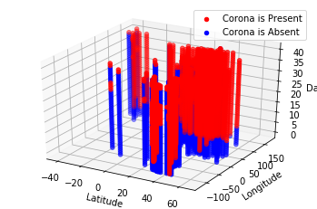

```python
from mpl_toolkits import mplot3d
import numpy as np
import matplotlib.pyplot as plt

fig = plt.figure()
ax = plt.axes(projection="3d")


ax.scatter3D(df[df["Results"]=="Present"]["Lat"].values,df[df["Results"]=="Present"]["Long"].values,
             df[df["Results"]=="Present"]["DateLE"].values,cmap='hsv',c='red',label='Corona is Present')

ax.scatter3D(df[df["Results"]=="Absent"]["Lat"].values,df[df["Results"]=="Absent"]["Long"].values,
             df[df["Results"]=="Absent"]["DateLE"].values,cmap='hsv',c='blue',label='Corona is Absent')


ax.legend()

ax.set_xlabel('Latitude')
ax.set_ylabel('Longitude')
ax.set_zlabel('Date')

plt.show()
```

## Step 3- Spliting of Data (Train and Test)

#### To split the data we are importing train_test_split function from sklearn.model_selection class this function divide the dataset into training set and testing set at 80%-20%

```python
from sklearn.model_selection import train_test_split

X_train,X_test,Y_train,Y_test=train_test_split(df.loc[:,["Lat","Long","DateLE"]].values,df["Results"].values,test_size=0.20,random_state=0)
```

```python
X_train,X_test,Y_train,Y_test
```

```
(array([[  38.0428,  114.5149,    7.    ],
        [  33.4255, -111.94  ,    3.    ],
        [  43.7333,    7.4167,    3.    ],
        ...,
        [  46.8182,    8.2275,   21.    ],
        [ -28.0167,  153.4   ,   38.    ],
        [  23.7   ,  121.    ,   11.    ]]),
 array([[  56.8796,   24.6032,    5.    ],
        [  32.7157, -117.1611,   15.    ],
        [  40.7128,  -74.006 ,   12.    ],
        ...,
        [  47.    ,    2.    ,   39.    ],
        [  23.3417,  113.4244,   24.    ],
        [  36.0611,  103.8343,   18.    ]]),
 array(['Present', 'Absent', 'Absent', ..., 'Absent', 'Present', 'Present'],
       dtype=object),
 array(['Absent', 'Present', 'Absent', ..., 'Present', 'Present',
        'Present'], dtype=object))
```

## Step 4- Model Building and Predicting

#### In order to bulid a model first we have to import GaussianNB classifier from sklearn.naive_bayes

#### Fitting the classifier to the Training Set

```python
from sklearn.naive_bayes import GaussianNB
classifier=GaussianNB()
classifier.fit(X_train,Y_train)
```

```
GaussianNB(priors=None, var_smoothing=1e-09)
```

#### Predicting the Test set result and Displaying the Confusion Matrix

```python
y_pred=classifier.predict(X_test)

from sklearn.metrics import confusion_matrix,accuracy_score
cm=confusion_matrix(Y_test,y_pred)
cm
```

```
array([[366, 190],
       [142, 467]])
```

#### Model Accuracy

```python
print("Accuracy:",accuracy_score(Y_test, y_pred)*100)
```

```
Accuracy: 71.50214592274679
```

## Step 5- Cross Validation Score

#### For this cross validation we import cross_val_scorce which is inside sklearn.model_selection

```python
from sklearn.model_selection import cross_val_score
accuracies=cross_val_score(estimator=classifier,X=X_train,y=Y_train,cv=10)
print("Final Accuracy is :",accuracies.mean()*100)
```

```
Final Accuracy is : 72.44976694817481
```

**You have reached end of the Project!**